# EM explanation

We use a simple EM algorithm approach to reconstruct daily incidence data from temporally aggregated data, without introducing bias into R<sub>t</sub> estimates. This vignette provides a short breakdown of how the algorithm works “under the hood” (code is all within the `estimate_R()` function in EpiEstim), but to see a vignette for how the algorithm is applied in EpiEstim, visit:  
https://mrc-ide.github.io/EpiEstim/articles/EpiEstim_aggregated_data.html.  
The function `estimate_R_agg()` which implements the process below within `estimate_R()` can be found here:  
https://github.com/mrc-ide/EpiEstim/blob/master/R/estimate_R_agg.R

Here, we will use weekly data to demonstrate the steps of the EM algorithm (as shown in Figure 1), but the approach can be applied to any aggregation of incidence data.

```r
# Fake aggregated incidence
weekly_inc <- readRDS("weekly_dat.rds")

# Serial interval
method <- "parametric_si"
mean_si <- 3.6
sd_si <- 1.6

# Default number of iterations used
iter <- 10
```

## Step 1: Initiation

The EM algorithm is initialised with a naive disaggregation of the incidence:

```r
dt <- 7 # Aggregation window
dis <- weekly_inc / dt # Naive disaggregation

dis_inc <- rep(dis, each = dt)
day <- seq_along(dis_inc)
dis_data <- data.frame(dis_inc, day)
```

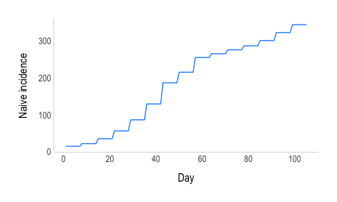

Fig.1. Naive reconstruction of daily incidence

## Step 2: Expectation

The current reconstructed daily incidence (in the first iteration this is the naive incidence) is then used to estimate the expected reproduction number for each aggregation window R<sub>w</sub>, obtained as the posterior mean from EpiEstim.

```r
n_dt <- length(weekly_inc) # number of aggregation windows
T <- n_dt * dt
t_start <- seq(from = dt + 1, to = T - (dt - 1), dt)
t_end <- seq(from = min(t_start) + (dt - 1), to = T, dt)
result_R_w <- estimate_R(dis_inc,
                  method = method,
                  config = list(mean_si = mean_si,
                                std_si = sd_si,
                                t_start = t_start,
                                t_end = t_end))
r_w <- rep(result_R_w$R$`Mean(R)`, each = dt)
r_w_day <- day[-c(1:7)] # can't estimate R for first aggregation window
dat_r_w <- data.frame(r_w, r_w_day)
```

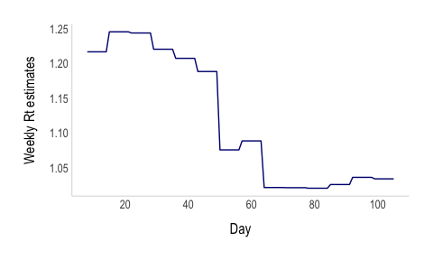

Fig.2. R<sub>w</sub> estimates for the first iteration

## Step 3: Maximisation

Conditional on R<sub>w</sub> the most likely daily incidence is reconstructed.

First, R<sub>w</sub> is translated into a growth rate for that week (r<sub>w</sub>) using Wallinga and Lipsitch’s method<sup>1</sup>. This is implemented using a function called `get_r_from_R()`:

```r
get_r_from_R <- function(R,
                         gt_mean,
                         gt_sd,
                         gt_distr = NULL,
                         grid = list(precision = 0.001, min = -1, max = 1)) {
        r_grid <- seq(grid$min, grid$max, grid$precision)
        if (is.null(gt_distr)) {
          gt_pars <- epitrix::gamma_mucv2shapescale(mu = gt_mean,
                                                    cv = gt_sd / gt_mean)
          gt_distr <- distcrete::distcrete("gamma", interval = 1,
                                           shape = gt_pars$shape,
                                           scale = gt_pars$scale, w = 0.5)
        }
        # using a grid of r values translate that into R using r2R0
        R_grid <- epitrix::r2R0(r = r_grid, w = gt_distr)
        # find location of the value in the R grid which has the smallest
        # difference to the input of R the user provided e.g. R_grid[idx_r]:
        idx_r <- vapply(R, function(e) which.min(abs(R_grid - e)), numeric(1L))
        while (any(idx_r == 1) || any(idx_r == length(r_grid))) {
          # if necessary rerun get_r_from_R with a wider r_grid
          grid_multiplier <- 5
          if (grid$max > 0) grid$max <- grid_multiplier * grid$max else
            grid$max <- - grid$max
          if (grid$min < 0) grid$min <- grid_multiplier * grid$min else
            grid$min <- - grid$min
          r_grid <- seq(grid$min, grid$max, grid$precision)
          R_grid <- r2R0(r = r_grid, w = gt_distr)
          idx_r <- vapply(R, function(e) which.min(abs(R_grid - e)), numeric(1L))
        }
        r <- vapply(idx_r, function(e) r_grid[e], numeric(1L))
      }
```

```r
Mean_R <- result_R_w$R$`Mean(R)`
gr <- get_r_from_R(R = Mean_R,
                   gt_mean = mean_si,
                   gt_sd = sd_si)
```

The incidence for each week is then computed assuming exponential growth, with a multiplying constant k<sub>w</sub> that ensures that, if incidence were to be reaggregated, the reconstructed incidence will still match the original weekly incidence supplied.

One caveat to this method, is that it does not allow incidence to be reconstructed for the first aggregation window, as there is no past incidence data to estimate R<sub>w</sub> for it. This could be further pushed back if incidence is too low to estimate R<sub>w</sub> beyond the first aggregation window. The user can choose to either:

1. keep the naive disaggregation of the the incidence for the aggregation window(s) which precede the first window that R can be estimated for, or
2. reconstruct the incidence in the preceding aggregation window by assuming the growth rate matches that of the first estimation window. Here, we will assume that the user chose option 2 (which would be specified in EpiEstim using `recon_opt = "match"` in `estimate_R()`).

```r
# Note: this is all encoded within estimate_R_agg(), which is called by estimate_R()

# Matrix for the reconstructed incidence generated after each iteration
sim_inc <- matrix(NA, nrow = T, ncol = iter)

# Identify which aggregation windows R could be estimated for
# (in this case all but the first)
 if (anyNA(Mean_R)){
   idx_na <- which(is.na(Mean_R))
   idx_reconstruct <- seq(min(result_R_w$R$t_start[-idx_na]), length(dis_inc))
   Mean_R <- Mean_R[!is.na(Mean_R)]
   } else {
     idx_reconstruct <- seq(min(result_R_w$R$t_start), length(dis_inc))
   }

# Index for aggregation windows
full_dt <- rep(dt, n_dt)
idx_aggregation <- rep(seq(1 : n_dt), times = full_dt)

# If recon_opt = "match" in estimate_R()
aggs_with_estimate <- seq(idx_aggregation[idx_reconstruct[1]], n_dt)
aggs_to_reconstruct <- c(aggs_with_estimate[1] - 1, aggs_with_estimate)
add_idx <- rev((min(idx_reconstruct) - 1) : (min(idx_reconstruct) - dt))
idx_reconstruct <- c(add_idx, idx_reconstruct)
# assuming growth rate in first week matches the first estimation window
gr <- c(gr[1], gr)

# Aggregated incidence that can be reconstructed (in this case all incidence)
incid_to_reconstruct <- weekly_inc[aggs_to_reconstruct]
dt_seq <- full_dt[aggs_to_reconstruct]

# Constant kw ensures that, if re-aggregated, totals match original aggregations
d <- numeric(length(aggs_to_reconstruct))
k <- numeric(length(aggs_to_reconstruct))
for (w in seq_along(k)){
  d[w] <- sum(exp(gr[w] * seq(1, dt_seq[w] - 1, 1)))
  k[w] <- incid_to_reconstruct[w] / (exp(gr[w]) * (1 + d[w]))
}

recon_df <- data.frame(k = k, gr = gr, dt = dt_seq)

# Create sequences of k and gr matching the length of each dt
k_ls <- list()
gr_ls <- list()
for (f in seq_along(incid_to_reconstruct)){
  k_ls[[f]] <- rep(recon_df$k[f], recon_df$dt[f])
  gr_ls[[f]] <- rep(recon_df$gr[f], recon_df$dt[f])
}
k_seq <- unlist(k_ls)
gr_seq <- unlist(gr_ls)

# Create aggregation day index
w_day <- list()
for (x in seq_along(dt_seq)){
  w_day[[x]] <- seq(1, dt_seq[x])
}
w_day <- unlist(w_day)

# Reconstruct daily incidence
recon_days <- seq(1, sum(dt_seq))
est_inc <- rep(NA, length(recon_days))

for (t in seq_along(recon_days)){
  est_inc[t] <- k_seq[t] * exp(gr_seq[t] * w_day[t])
}

sim_inc[,1] <- est_inc
message("Reconstructed incidence for iteration: ", 1)
```

```
#> Reconstructed incidence for iteration: 1
```

The process is repeated iteratively, where each iteration starts with the new reconstructed incidence generated in the previous iteration:

```r
new_inc <- sim_inc[,1]

# Re-estimate R for each aggregation window using this new incidence
R <- estimate_R(new_inc,
                method = method,
                config = list(mean_si = mean_si,
                              std_si = sd_si,
                              t_start = t_start,
                              t_end = t_end))

# And the process repeats exactly as above until convergence
```

After 10 iterations, the matrix of reconstructed incidence is complete:

```r
head(sim_inc)
```

```
#>          [,1]     [,2]     [,3]     [,4]     [,5]     [,6]     [,7]     [,8]
#> [1,] 12.00107 11.84695 11.80862 11.80862 11.80862 11.80862 11.80862 11.80862
#> [2,] 12.69231 12.57953 12.55137 12.55137 12.55137 12.55137 12.55137 12.55137
#> [3,] 13.42336 13.35740 13.34083 13.34083 13.34083 13.34083 13.34083 13.34083
#> [4,] 14.19651 14.18338 14.17996 14.17996 14.17996 14.17996 14.17996 14.17996
#> [5,] 15.01420 15.06043 15.07186 15.07186 15.07186 15.07186 15.07186 15.07186
#> [6,] 15.87898 15.99172 16.01987 16.01987 16.01987 16.01987 16.01987 16.01987
#>          [,9]    [,10]
#> [1,] 11.80862 11.80862
#> [2,] 12.55137 12.55137
#> [3,] 13.34083 13.34083
#> [4,] 14.17996 14.17996
#> [5,] 15.07186 15.07186
#> [6,] 16.01987 16.01987
```

A convergence check ensures that the incidence generated in the final iteration does not differ from the previous iteration beyond a tolerance of 10<sup>-6</sup>.

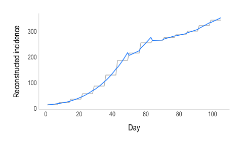

Fig.3. Reconstructed incidence after 10 iterations (blue) compared to the naively disaggregated incidence (grey)

Finally, the algorithm takes the latest reconstructed incidence and estimates the full posterior distribution of R<sub>t</sub> using EpiEstim.

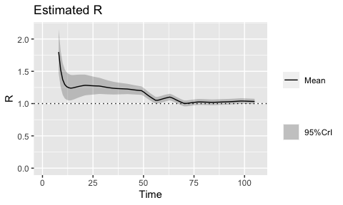

Fig.4. R estimate using the final daily reconstructed incidence

## References

1. Wallinga J, Lipsitch M. How generation intervals shape the relationship between growth rates and reproductive numbers. Proc Biol Sci. 2007 Feb 22;274(1609):599–604.